# Working report

This R markdown report contains general summaries of questions by demographics.

# Survey questions

### Q1. Before receiving this survey, did you know influenza is different from the stomach flu?

```r
## PPGENDER
# oddsratio with reversed columns
a = with(data2, table(PPGENDER, Q1))
oddsratio(a, rev = "columns")
```

```
## $data
##         Q1
## PPGENDER  Yes  No Total
##   Female  888 205  1093
##   Male    776 283  1059
##   Total  1664 488  2152
##
## $measure
##         odds ratio with 95% C.I.
## PPGENDER estimate lower upper
##   Female     1.00    NA    NA
##   Male       1.58  1.29  1.94
##
## $p.value
##         two-sided
## PPGENDER midp.exact fisher.exact chi.square
##   Female         NA           NA         NA
##   Male     1.02e-05     1.16e-05   1.02e-05
##
## $correction
## [1] FALSE
##
## attr(,"method")
## [1] "median-unbiased estimate & mid-p exact CI"
```

```r
# SPSS table: joint freq, conditional %, marginal prop
with(data2, CrossTable(PPGENDER, Q1, prop.chisq = F))
```

```
##
##
##    Cell Contents
## |-------------------------|
## |                       N |
## |           N / Row Total |
## |           N / Col Total |
## |         N / Table Total |
## |-------------------------|
##
##
## Total Observations in Table:  2152
##
##
##              | Q1
##     PPGENDER |        No |       Yes | Row Total |
## -------------|-----------|-----------|-----------|
##       Female |       205 |       888 |      1093 |
##              |     0.188 |     0.812 |     0.508 |
##              |     0.420 |     0.534 |           |
##              |     0.095 |     0.413 |           |
## -------------|-----------|-----------|-----------|
##         Male |       283 |       776 |      1059 |
##              |     0.267 |     0.733 |     0.492 |
##              |     0.580 |     0.466 |           |
##              |     0.132 |     0.361 |           |
## -------------|-----------|-----------|-----------|
## Column Total |       488 |      1664 |      2152 |
##              |     0.227 |     0.773 |           |
## -------------|-----------|-----------|-----------|
##
##
```

```r
# xtab table
xtab(PPGENDER ~ Q1, data2)
```

```
## Crosstabulation of PPGENDER by Q1
##  Q1
## PPGENDER     No    Yes
## Female    205    888   1093
##    18.76  81.24      -
##     42.0   53.4   50.8
##
## Male      283    776   1059
##    26.72  73.28      -
##     58.0   46.6   49.2
##
##      488   1664   2152
##     22.7   77.3  100.0
## odds ratio = 0.63
## relative risk (PPGENDER-Male) = 0.9
```

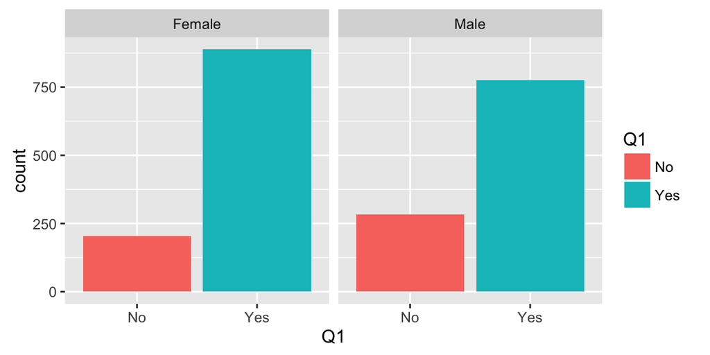

```r
# plot
g1 + geom_bar(mapping = aes(x = Q1, fill = Q1), position = position_dodge()) + facet_wrap(~PPGENDER)
```

```r
## PPEDUCAT
xtab(PPEDUCAT ~ Q1, data2)
```

```
## Crosstabulation of PPEDUCAT by Q1
##  Q1
## PPEDUCAT     No    Yes
## Less than high school           56    106    162
##    34.57  65.43      -
##    11.48   6.37   7.53
##
## High school                    192    438    630
##    30.48  69.52      -
##     39.3   26.3   29.3
##
## Some college                   113    492    605
##    18.68  81.32      -
##     23.2   29.6   28.1
##
## Bachelor_s degree or higher    127    628    755
##    16.82  83.18      -
##     26.0   37.7   35.1
##
##      488   1664   2152
##     22.7   77.3  100.0
```

```r
with(data2, table(PPEDUCAT, Q1, useNA = "ifany"))
```

```
##                              Q1
## PPEDUCAT                       No Yes <NA>
##   Less than high school        56 106    2
##   High school                 192 438    4
##   Some college                113 492    6
##   Bachelor_s degree or higher 127 628    4
```

```r
## PPETHM
xtab(PPETHM ~ Q1, data2)
```

```
## Crosstabulation of PPETHM by Q1
##  Q1
## PPETHM     No    Yes
## White, Non-Hispanic       322   1235   1557
##    20.68  79.32      -
##     66.0   74.2   72.3
##
## Black, Non-Hispanic        50    143    193
##    25.91  74.09      -
##    10.25   8.59   8.97
##
## Hispanic                   69    161    230
##       30     70      -
##    14.14   9.68  10.69
##
## Other, Non-Hispanic        29     63     92
##    31.52  68.48      -
##     5.94   3.79   4.28
##
## 2+ Races, Non-Hispanic     18     62     80
##     22.5   77.5      -
##     3.69   3.73   3.72
##
##      488   1664   2152
##     22.7   77.3  100.0
```

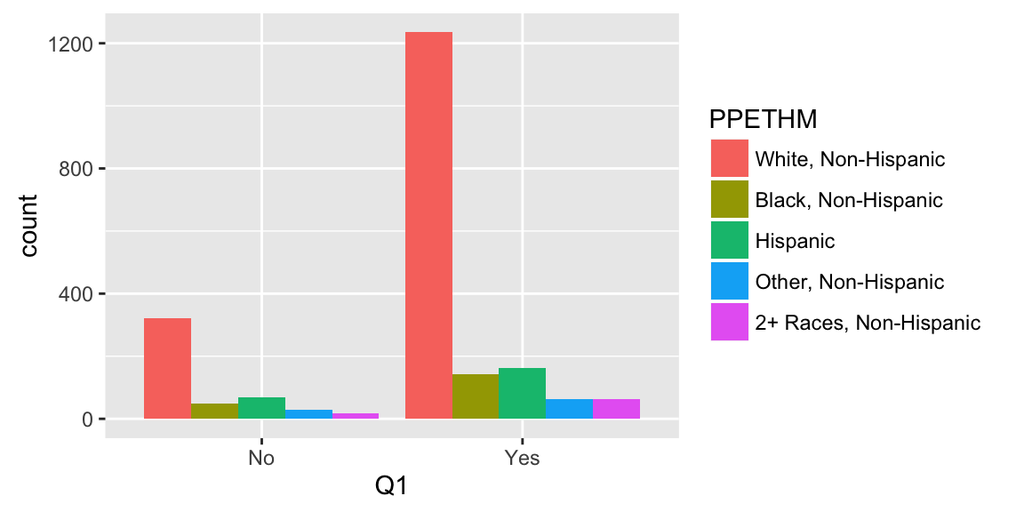

```r
g1 + geom_bar(mapping = aes(x = Q1, fill = PPETHM), position = position_dodge())
```

```r
## PPINCIMP
xtab(PPINCIMP ~ Q1, data2)
```

```
## Crosstabulation of PPINCIMP by Q1
##  Q1
## PPINCIMP     No    Yes
## Less than $5,000         22     30     52
##    42.31  57.69      -
##     4.51   1.80   2.42
##
## $5,000 to $7,499          8     16     24
##    33.33  66.67      -
##     1.64   0.96   1.12
##
## $7,500 to $9,999          7      7     14
##       50     50      -
##     1.43   0.42   0.65
##
## $10,000 to $12,499       17     39     56
##    30.36  69.64      -
##     3.48   2.34   2.60
##
## $12,500 to $14,999       10     38     48
##    20.83  79.17      -
##     2.05   2.28   2.23
##
## $15,000 to $19,999       22     40     62
##    35.48  64.52      -
##     4.51   2.40   2.88
##
## $20,000 to $24,999       16     55     71
##    22.54  77.46      -
##     3.28   3.31   3.30
##
## $25,000 to $29,999       23     76     99
##    23.23  76.77      -
##     4.71   4.57   4.60
##
## $30,000 to $34,999       21     70     91
##    23.08  76.92      -
##     4.30   4.21   4.23
##
## $35,000 to $39,999       31     72    103
```

[output cut: 26 more lines]

```
##
## $125,000 to $149,999     24    108    132
##    18.18  81.82      -
##     4.92   6.49   6.13
##
## $150,000 to $174,999     16     68     84
##    19.05  80.95      -
##     3.28   4.09   3.90
##
## $175,000 or more         18    107    125
##     14.4   85.6      -
##     3.69   6.43   5.81
##
##      488   1664   2152
##     22.7   77.3  100.0
```

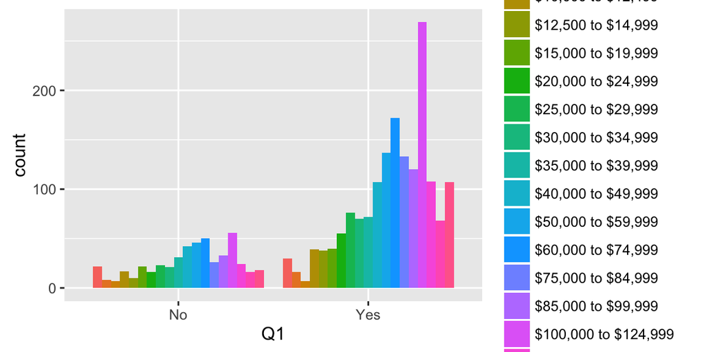

```r
g1 + geom_bar(mapping = aes(x = Q1, fill = PPINCIMP), position = position_dodge())
```

### Q2. Have you had an illness with influenza-like symptoms since August 2015?

```
## Crosstabulation of PPGENDER by Q2
##  Q2
## PPGENDER     No    Yes
## Female    858    234   1092
##    78.57  21.43      -
##     49.5   56.5   50.8
##
## Male      877    180   1057
##    82.97  17.03      -
##     50.5   43.5   49.2
##
##     1735    414   2149
##     80.7   19.3  100.0
## odds ratio = 0.75
## relative risk (PPGENDER-Male) = 0.79
```

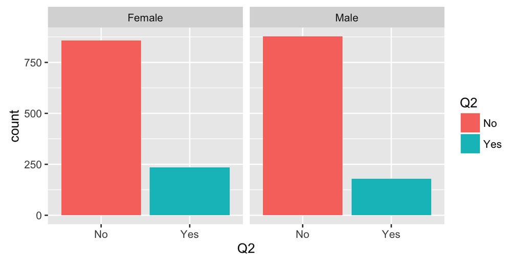

```
## Crosstabulation of PPETHM by Q2
##  Q2
## PPETHM     No    Yes
## White, Non-Hispanic      1287    269   1556
##    82.71  17.29      -
##     74.2   65.0   72.4
##
## Black, Non-Hispanic       152     39    191
##    79.58  20.42      -
##     8.76   9.42   8.89
##
## Hispanic                  164     65    229
##    71.62  28.38      -
##     9.45  15.70  10.66
##
## Other, Non-Hispanic        71     22     93
##    76.34  23.66      -
##     4.09   5.31   4.33
##
## 2+ Races, Non-Hispanic     61     19     80
##    76.25  23.75      -
##     3.52   4.59   3.72
##
##     1735    414   2149
##     80.7   19.3  100.0
```

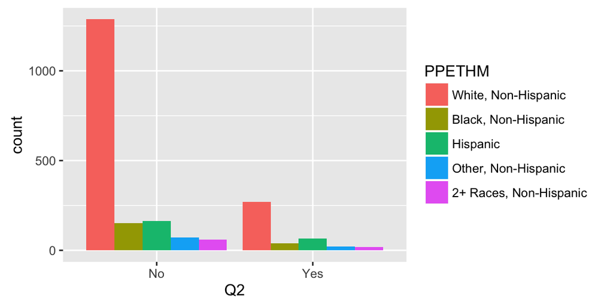

```
## Crosstabulation of PPINCIMP by Q2
##  Q2
## PPINCIMP     No    Yes
## Less than $5,000         43      9     52
##    82.69  17.31      -
##     2.48   2.17   2.42
##
## $5,000 to $7,499         19      6     25
##       76     24      -
##     1.10   1.45   1.16
##
## $7,500 to $9,999         13      1     14
##    92.86   7.14      -
##     0.75   0.24   0.65
##
## $10,000 to $12,499       38     17     55
##    69.09  30.91      -
##     2.19   4.11   2.56
##
## $12,500 to $14,999       39      9     48
##    81.25  18.75      -
##     2.25   2.17   2.23
##
## $15,000 to $19,999       46     15     61
##    75.41  24.59      -
##     2.65   3.62   2.84
##
## $20,000 to $24,999       55     17     72
##    76.39  23.61      -
##     3.17   4.11   3.35
##
## $25,000 to $29,999       79     19     98
##    80.61  19.39      -
##     4.55   4.59   4.56
##
## $30,000 to $34,999       74     18     92
##    80.43  19.57      -
##     4.27   4.35   4.28
##
## $35,000 to $39,999       85     18    103
```

[output cut: 26 more lines]

```
##
## $125,000 to $149,999    112     20    132
##    84.85  15.15      -
##     6.46   4.83   6.14
##
## $150,000 to $174,999     62     21     83
##     74.7   25.3      -
##     3.57   5.07   3.86
##
## $175,000 or more        104     21    125
##     83.2   16.8      -
##     5.99   5.07   5.82
##
##     1735    414   2149
##     80.7   19.3  100.0
```

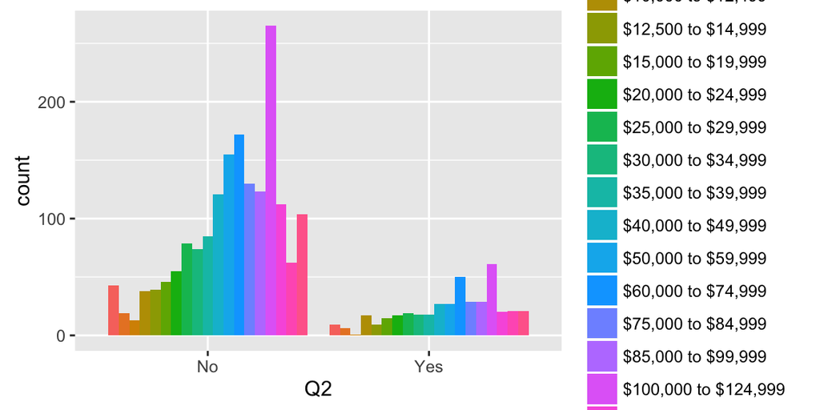

### Q3. Has any other person in your household had an illness with influenza like symptoms since August 2015?

```
## Q3
## Don_t know         No        Yes
##        161       1608        383
```

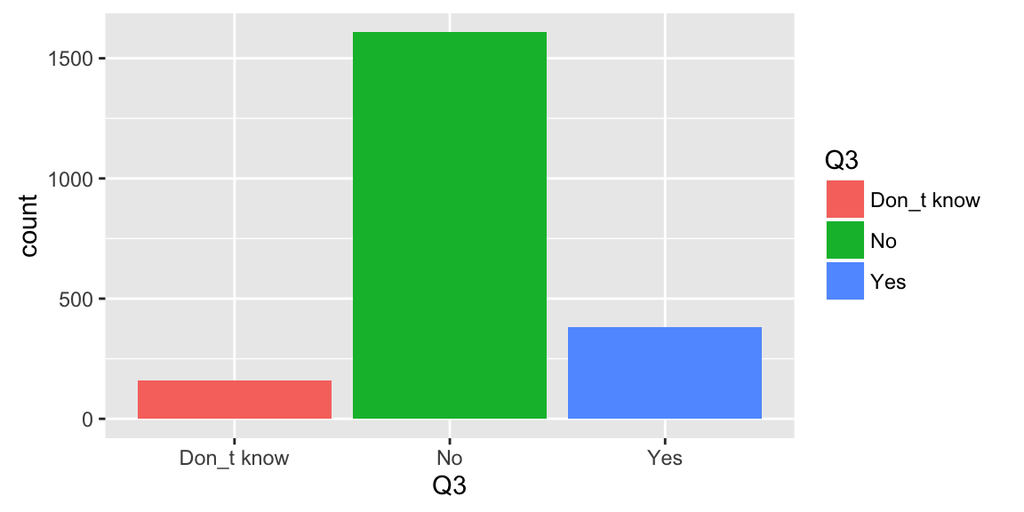

```
##         Q3
## PPGENDER Don_t know  No Yes
##   Female         72 804 217
##   Male           89 804 166
```

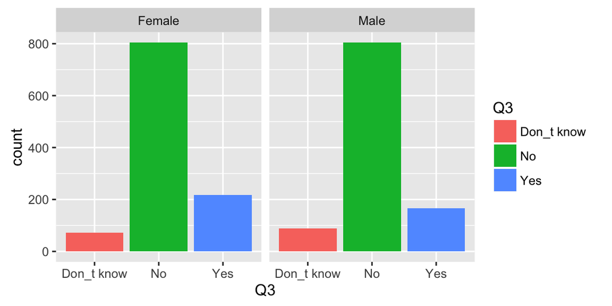

```
##                         Q3
## PPETHM                   Don_t know   No  Yes
##   White, Non-Hispanic            95 1197  265
##   Black, Non-Hispanic            19  149   25
##   Hispanic                       30  146   53
##   Other, Non-Hispanic            11   59   23
##   2+ Races, Non-Hispanic          6   57   17
```

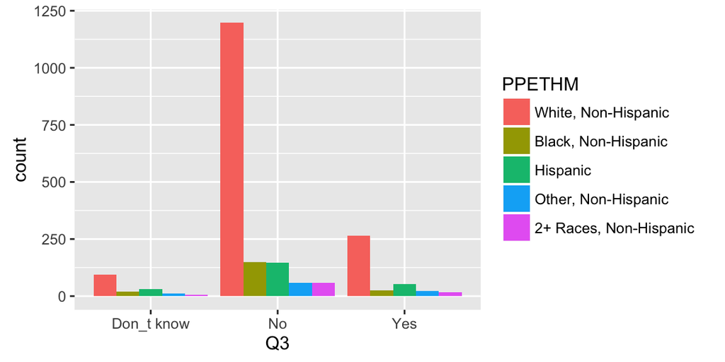

```
##                       Q3
## PPINCIMP               Don_t know  No Yes
##   Less than $5,000             11  36   5
##   $5,000 to $7,499              6  18   1
##   $7,500 to $9,999              1  13   0
##   $10,000 to $12,499            4  44   8
##   $12,500 to $14,999            7  30  11
##   $15,000 to $19,999            7  47   8
##   $20,000 to $24,999            8  52  12
##   $25,000 to $29,999            4  81  13
##   $30,000 to $34,999           11  70   9
##   $35,000 to $39,999           11  75  17
##   $40,000 to $49,999            6 117  25
##   $50,000 to $59,999           13 136  33
##   $60,000 to $74,999           18 165  39
##   $75,000 to $84,999            7 120  33
##   $85,000 to $99,999           11 107  35
##   $100,000 to $124,999         20 245  61
##   $125,000 to $149,999          6 100  26
##   $150,000 to $174,999          3  58  23
##   $175,000 or more              7  94  24
```

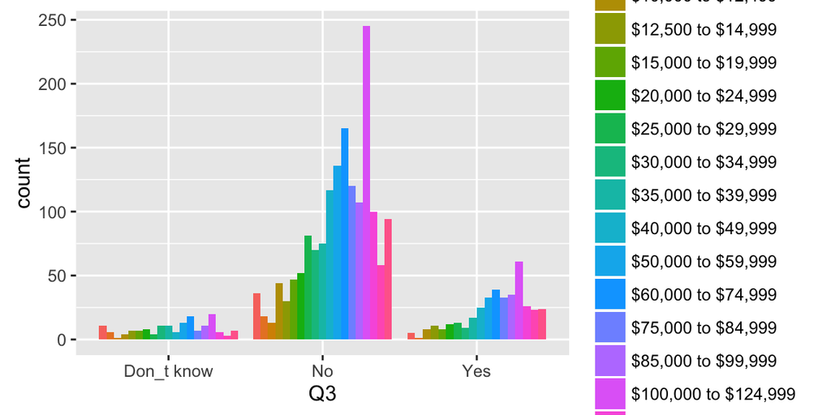

### Q4. Does your job require you to have a lot of contact with the public?

```
## Q4
##                                         No, I don_t work
##                                                      779
## No, my job does not require much contact with the public
##                                                      620
##                                                      Yes
##                                                      751
```

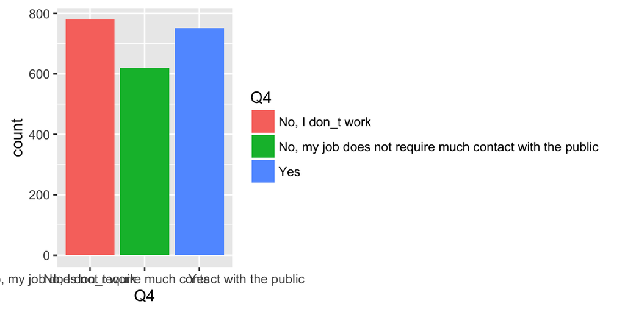

```
##         Q4
## PPGENDER No, I don_t work
##   Female              430
##   Male                349
##         Q4
## PPGENDER No, my job does not require much contact with the public Yes
##   Female                                                      263 400
##   Male                                                        357 351
```

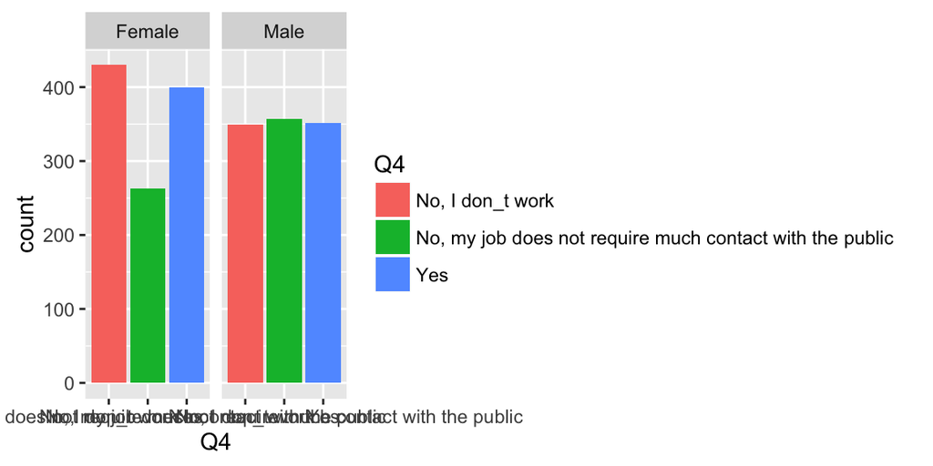

```
##                         Q4
## PPETHM                   No, I don_t work
##   White, Non-Hispanic                 587
##   Black, Non-Hispanic                  69
##   Hispanic                             69
##   Other, Non-Hispanic                  24
##   2+ Races, Non-Hispanic               30
##                         Q4
## PPETHM                   No, my job does not require much contact with the public
##   White, Non-Hispanic                                                         432
##   Black, Non-Hispanic                                                          59
##   Hispanic                                                                     72
##   Other, Non-Hispanic                                                          34
##   2+ Races, Non-Hispanic                                                       23
##                         Q4
## PPETHM                   Yes
##   White, Non-Hispanic    538
##   Black, Non-Hispanic     64
##   Hispanic                87
##   Other, Non-Hispanic     35
##   2+ Races, Non-Hispanic  27
```

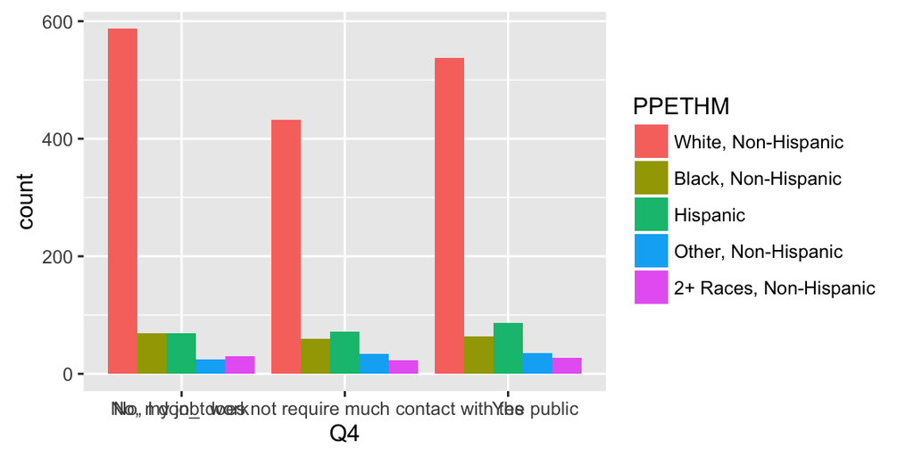

```
##                       Q4
## PPINCIMP               No, I don_t work
##   Less than $5,000                   29
##   $5,000 to $7,499                   15
##   $7,500 to $9,999                   11
##   $10,000 to $12,499                 33
##   $12,500 to $14,999                 32
##   $15,000 to $19,999                 28
##   $20,000 to $24,999                 35
##   $25,000 to $29,999                 46
##   $30,000 to $34,999                 38
##   $35,000 to $39,999                 42
##   $40,000 to $49,999                 64
##   $50,000 to $59,999                 60
##   $60,000 to $74,999                 73
##   $75,000 to $84,999                 45
##   $85,000 to $99,999                 47
##   $100,000 to $124,999               87
##   $125,000 to $149,999               39
##   $150,000 to $174,999               23
##   $175,000 or more                   32
##                       Q4
## PPINCIMP               No, my job does not require much contact with the public
##   Less than $5,000                                                           17
##   $5,000 to $7,499                                                            5
##   $7,500 to $9,999                                                            1
##   $10,000 to $12,499                                                          7
##   $12,500 to $14,999                                                          5
##   $15,000 to $19,999                                                         13
##   $20,000 to $24,999                                                         18
##   $25,000 to $29,999                                                         15
##   $30,000 to $34,999                                                         25
##   $35,000 to $39,999                                                         22
##   $40,000 to $49,999                                                         41
##   $50,000 to $59,999                                                         58
##   $60,000 to $74,999                                                         60
##   $75,000 to $84,999                                                         51
##   $85,000 to $99,999                                                         48
##   $100,000 to $124,999                                                      111
##   $125,000 to $149,999                                                       51
```

[output cut: 8 more lines]

```
##   $12,500 to $14,999    11
##   $15,000 to $19,999    21
##   $20,000 to $24,999    19
##   $25,000 to $29,999    37
##   $30,000 to $34,999    29
##   $35,000 to $39,999    39
##   $40,000 to $49,999    43
##   $50,000 to $59,999    63
##   $60,000 to $74,999    88
##   $75,000 to $84,999    64
##   $85,000 to $99,999    58
##   $100,000 to $124,999 127
##   $125,000 to $149,999  42
##   $150,000 to $174,999  36
##   $175,000 or more      46
```

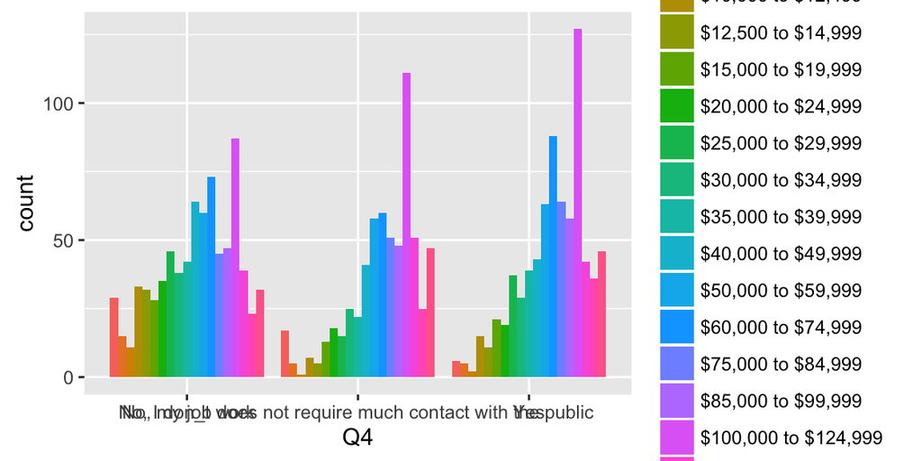

### Q5. Do you have a car that you can use to travel to work?

```
## Q5
##   No  Yes
##  133 1235
```

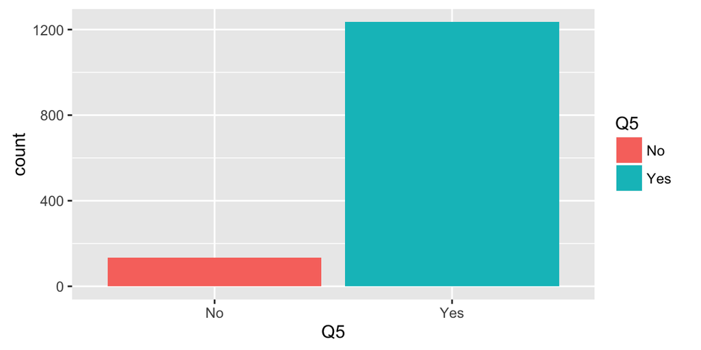

```
##         Q5
## PPGENDER  No Yes
##   Female  70 592
##   Male    63 643
```

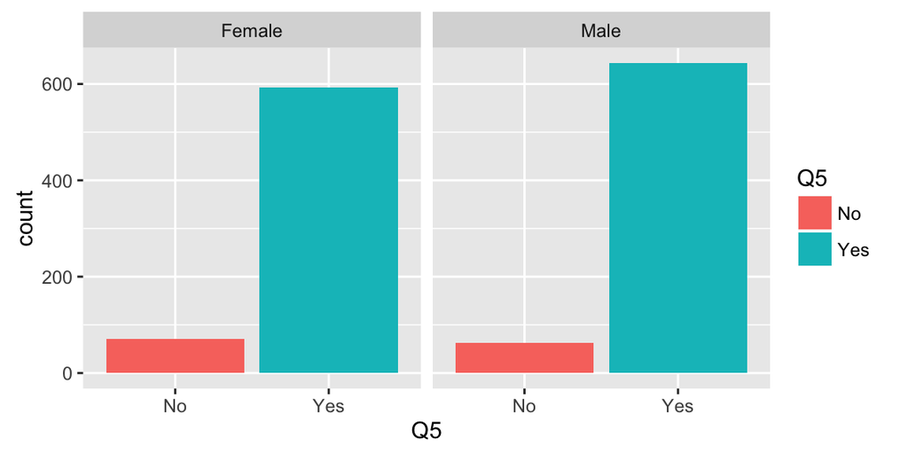

```
##                         Q5
## PPETHM                    No Yes
##   White, Non-Hispanic     72 895
##   Black, Non-Hispanic     22 101
##   Hispanic                24 135
##   Other, Non-Hispanic      8  61
##   2+ Races, Non-Hispanic   7  43
```

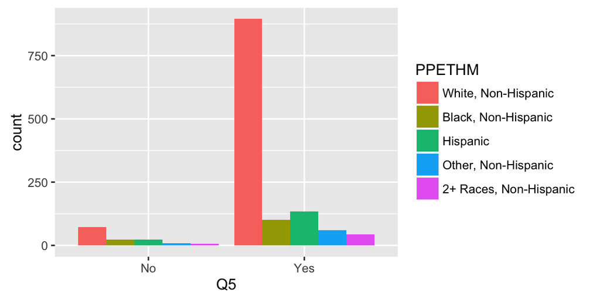

```
##                       Q5
## PPINCIMP                No Yes
##   Less than $5,000       6  17
##   $5,000 to $7,499       5   5
##   $7,500 to $9,999       1   2
##   $10,000 to $12,499     3  19
##   $12,500 to $14,999     3  13
##   $15,000 to $19,999     4  30
##   $20,000 to $24,999     6  30
##   $25,000 to $29,999     8  44
##   $30,000 to $34,999     7  47
##   $35,000 to $39,999     9  52
##   $40,000 to $49,999    11  72
##   $50,000 to $59,999    12 109
##   $60,000 to $74,999     9 138
##   $75,000 to $84,999    13 102
##   $85,000 to $99,999     8  98
##   $100,000 to $124,999   8 230
##   $125,000 to $149,999   5  88
##   $150,000 to $174,999   7  54
##   $175,000 or more       8  85
```

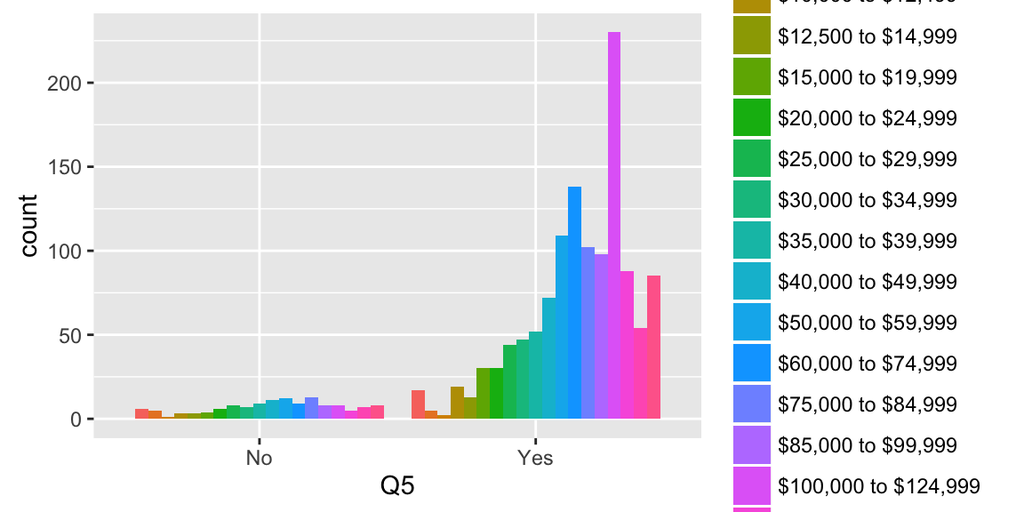

### Q6. Do you regularly use public transportation?

```
## Q6
##   No  Yes
## 1959  194
```

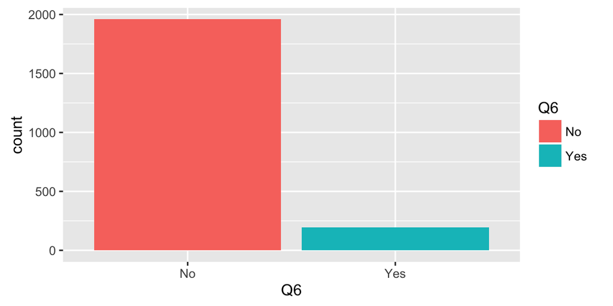

```
##         Q6
## PPGENDER  No Yes
##   Female 998  96
##   Male   961  98
```

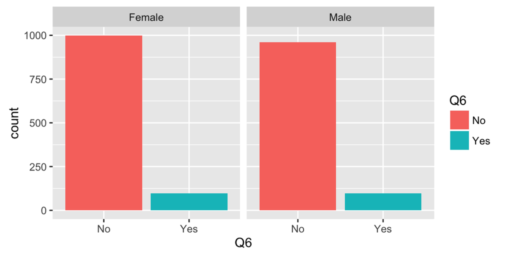

```
##                         Q6
## PPETHM                     No  Yes
##   White, Non-Hispanic    1463   95
##   Black, Non-Hispanic     158   36
##   Hispanic                196   32
##   Other, Non-Hispanic      80   13
##   2+ Races, Non-Hispanic   62   18
```

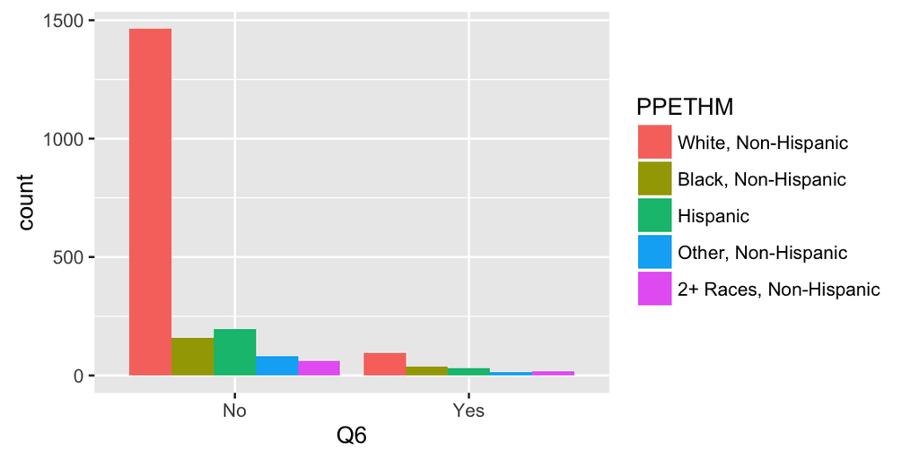

```
##                       Q6
## PPINCIMP                No Yes
##   Less than $5,000      42  10
##   $5,000 to $7,499      22   3
##   $7,500 to $9,999      10   4
##   $10,000 to $12,499    47   9
##   $12,500 to $14,999    42   5
##   $15,000 to $19,999    58   4
##   $20,000 to $24,999    64   8
##   $25,000 to $29,999    90   8
##   $30,000 to $34,999    85   7
##   $35,000 to $39,999    92  12
##   $40,000 to $49,999   141   7
##   $50,000 to $59,999   166  17
##   $60,000 to $74,999   200  20
##   $75,000 to $84,999   148  12
##   $85,000 to $99,999   142  11
##   $100,000 to $124,999 305  21
##   $125,000 to $149,999 123   9
##   $150,000 to $174,999  74  10
##   $175,000 or more     108  17
```

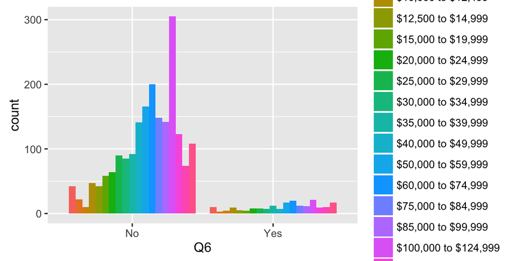